# DU_JIANWEI_FINAL_REPORT

Jianwei Du

5/10/2018

# 1 Introduction

This project was aimed at analyzing the offensive performance of NBA players with statistics. Given the huge stats dataset of NBA Official website, it is a natural idea to use technical skills, learned from class, for processing and analysis. With respect to the objective of “offensive performance”, this project focused on the shooting records, although there are other related data including assists and offensive rebounds.

The main deliverable is a Shiny app file, for interactive visualization and analysis of players from NBA team Golden States Warriors during 2016-17 Regular Season. R file for data collecting and cleaning is also attached, as well as cleaned dataset files.

# 2 Data Processing

All of the data processing was conducted in R file “*DU_JIANWEI_FINAL_DATA*”.

### 2.1 Data Collecting

The file named “*Player Regular 16-17 Stats.csv*” was used to extract “PLAYER_ID” data for further data collecting. Package rjson was adopted to collect shot logs from website, with player IDs. The preliminary processing was converting raw data to dataframe object.

### 2.2 Data Cleaning

Unnessary and outlier data were removed. As for the rest of data, levels or values of some of stats records were modified, and the “GAME_DATE” data were converted to object with type of Date. In the end, cleaned data was saved for analysis as “*Shotlog_GSW.csv*”.

# 3 Shiny

In order to achieve interactive visualization and analysis, Shiny was selected for the major part of the projet.

### 3.1 UI

There were 2 inputs. Since the project aimed at analysis for the whole team, one of the inputs was the `selectInput()`, with `choices` covering all of the player names, for selection among different players in Warriors. Furthermore, considering the dataset contained date data, `dateRangeInput()` was also added to UI, for analysis in different periods. Note that the `start` and `end` were determined by the season schedule.

The project had several plot and table outputs. Plot ouputs included “*Shot Chart*”, “*Shot Type*” and “*Shot Range*”. Note that “*Player Profile*” was also introduced, for advanced development of UI. Table outputs for “*Shot Type*” and “*Shot Range*” were added, while there were also tables for “*Summary*” and “*Hit Rate*”.

All the outputs were embed in different tabpanels, for advanced develompent of UI configuration.

### 3.2 Server

Given interactive environment, `reactive()` was used for data secondary processing, while `renderPlot()` and `renderDataTable()` were adopted for ouputs of plot and table.

# 4 Analysis

One player(e.g. Stephen Curry) was selected as example in this report.

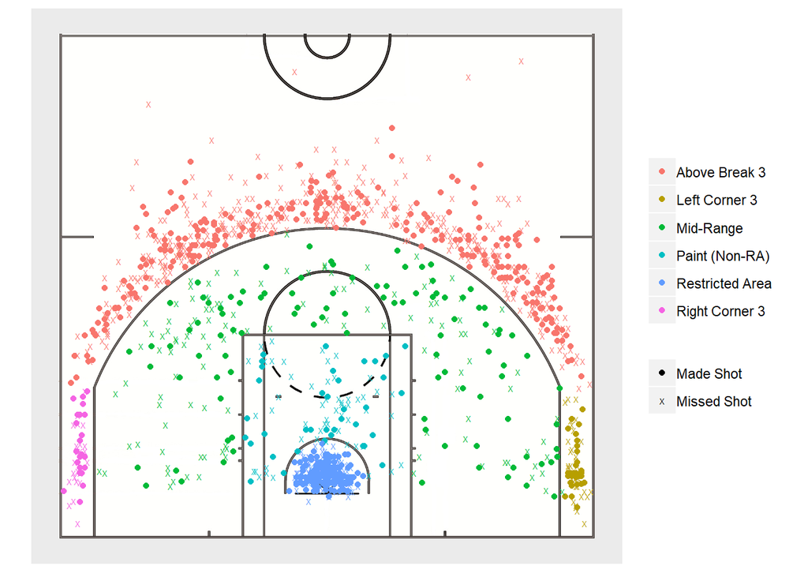

It is easy to see that this player is very good at shooting, especially for 3-pointers and scores in the restricetd aera.

- **Output 3-Summary**: descriptive stats for shot records using `summary()`.

```
##        EVENT_TYPE     ACTION_TYPE   SHOT_TYPE        SHOT_ZONE_BASIC
##  Made Shot  :673   Bank Shot:  23   2PT:654   Above Break 3  :655
##  Missed Shot:749   Dunk     :   4   3PT:768   Left Corner 3  : 67
##                    Fadeaway :  13             Mid-Range      :221
##                    Hook Shot:   6             Paint (Non-RA) : 92
##                    Jump Shot:1051             Restricted Area:341
##                    Layup    : 325             Right Corner 3 : 46
##   SHOT_ZONE_RANGE SHOT_DISTANCE
##  16-24 ft.:167    Min.   : 0.00
##  24+ ft.  :768    1st Qu.: 5.00
##  8- ft.   :389    Median :23.00
##  8-16 ft. : 98    Mean   :17.35
##                   3rd Qu.:25.00
##                   Max.   :43.00
```

The summary indicates the player is quite good at shooting, his favorite or best shot type is jump shot and 3-pointers, and his favorite shot areas, as well as numerical stats of his shot range and distance.

- **Output 4-Hit Rate Table**: general statistics analysis for shooting.

```
##     PT PT/Attmpt 2P/Attmpt 3P/Attmpt   FG%   2P%   3P%
## 1 1668      1.17      1.07      1.26 47.3% 53.7% 41.9%
```

“PT” is the total scores in that period. “PT/Attmpt”, “2P/Attmpt” and “3P/Attmpt” mean the scores per general attempt, 2-pointers attempt and 3-pointers attempt, respectively. These stats show the player’s ability and efficiency to shoot. “FG%”, “2P%” and “3P%” are general hit rate stats. Obviously, it shows that this player is really great at shooting, with high efficiency.

- **Output 5&6-Shot Type Plot&Table**: data visualization and statistic analysis for players skills in offense.

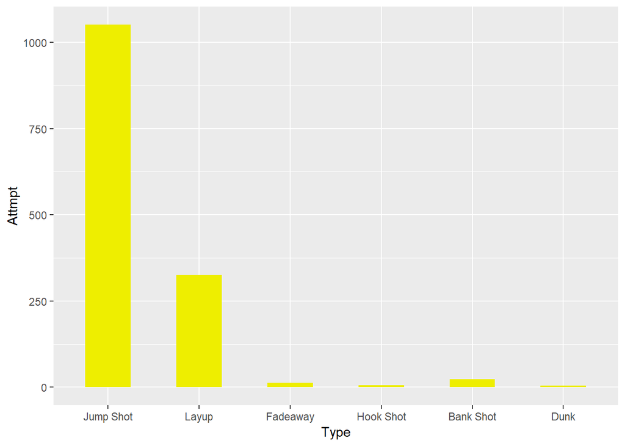

  |  | Type | Attmpt | FG% |
  | --- | --- | --- | --- |
  | 1 | Jump Shot | 1051 | 41.4% |
  | 2 | Layup | 325 | 64.3% |
  | 3 | Fadeaway | 13 | 53.8% |
  | 4 | Hook Shot | 6 | 33.3% |
  | 5 | Bank Shot | 23 | 73.9% |
  | 6 | Dunk | 4 | 75.0% |

- Output 7&8-Shot Range Plot&Table: data visualization and statistic analysis for players performance in different ranges.

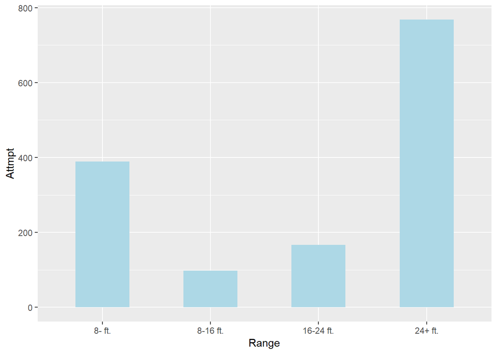

  |  | Range | Attmpt | FG% |
  | --- | --- | --- | --- |
  | 1 | 8- ft. | 389 | 59.6% |
  | 2 | 8-16 ft. | 98 | 43.9% |
  | 3 | 16-24 ft. | 167 | 45.5% |
  | 4 | 24+ ft. | 768 | 41.9% |

The plot in tis part shows that the 24+ ft. and 8- ft. are his favorite shooting aera. Almost of the attempts lie in these two ranges. With the table, again, it shows how effective and efficient he is at shooting in all kinds of ranges.

# End

R and other data analytics skills are trained during this project and more detailed analysis and interactive visulization can be seen with shiny app “*DU_JIANWEI_FINAL_Shiny.R*”. In the end, I wanna say Thank You to Josh for his patience and good lectures in this semester.